# Instance-level Variable Attributions

此資料描述員工的基本資料、工作情況、與職場問卷調查分數，欲分析員工離職的可能性以及影響離職的關鍵因素，以下是資料欄位的說明：

- `Attrition`: 員工是否離職（“Yes” 表示離職，“No” 表示未離職）為反應變數。
- `Age`: 員工年齡。
- `Gender`: 員工性別。
- `TotalWorkingYears`: 總工作年數。
- `YearsInCurrentRole`: 在當前職位上的工作年數。
- `YearsSinceLastPromotion`: 自上次晉升以來的年數。
- `DistanceFromHome`: 通勤距離。
- `JobLevel`: 職位等級。
- `MonthlyIncome`: 每月收入。
- `PercentSalaryHike`: 薪資漲幅百分比。
- `TrainingTimesLastYear`: 去年接受培訓的次數。
- `StockOptionLevel`: 股票期權等級。
- `EnvironmentSatisfaction`: 對工作環境的滿意度（數值表示，`1`-`4`）。
- `JobInvolvement`: 工作參與度（數值表示，`1`-`4`）。
- `JobSatisfaction`: 對工作的滿意度（數值表示，`1`-`4`）。
- `RelationshipSatisfaction`: 與同事或上司的關係滿意度（數值表示，`1`-`4`）。
- `WorkLifeBalance`: 工作與生活的平衡程度（數值表示，`1`-`4`）。

```python
# 匯入必要的套件
import os  # 用於作業系統相關的操作
from copy import deepcopy
import pandas as pd  # 用於處理和分析資料的資料框架工具
import numpy as np  # 用於數學計算，特別是陣列處理
from matplotlib import pyplot as plt  # 用於繪製圖表
```

讀取並預覽資料。

```python
# 從網路讀取 CSV 檔案並載入至 pandas DataFrame
att_df = pd.read_csv('https://raw.githubusercontent.com/PingYangChen/DS-pytutorial/refs/heads/main/sample_data/attrition.csv')  # 讀取名為 attrition.csv 的資料集
# 顯示資料集的前 5 行，用於檢查資料格式與內容
print(att_df.head(5))
# 計算資料集的總行數，確認資料量
print(len(att_df))
```

```
  Attrition  Age  Gender  TotalWorkingYears  YearsInCurrentRole  \
0       Yes   41  Female                  8                   4
1        No   49    Male                 10                   7
2       Yes   37    Male                  7                   0
3        No   33  Female                  8                   7
4        No   27    Male                  6                   2

   YearsSinceLastPromotion  DistanceFromHome  JobLevel  MonthlyIncome  \
0                        0                 1         2           5993
1                        1                 8         2           5130
2                        0                 2         1           2090
3                        3                 3         1           2909
4                        2                 2         1           3468

   PercentSalaryHike  TrainingTimesLastYear  StockOptionLevel  \
```

[output cut: 20 more lines]

資料中有類別型資料，先將其轉換為虛擬變數。

```python
# 篩選出類別型變數（判斷首筆資料的型別是否為字串）
categ_vars = [ele for ele in att_df.columns if type(att_df[ele].loc[0]) == type('is string')]
# 將類別變數轉換為虛擬變數（Dummy Variables），方便後續建模
att_df_dummy = pd.get_dummies(att_df, columns=categ_vars, drop_first=True, dtype=int)
```

建立分類器模型，在此以 XGBoost 為例，可自由切換其他 scikit-learn 樣式的分類器。

```python
# 定義目標變數 y 和特徵變數 x
y = att_df_dummy['Attrition_Yes']  # 目標變數（員工是否離職）
x = att_df_dummy[np.setdiff1d(att_df_dummy.columns, ['Attrition_Yes']).tolist()]  # 排除目標變數後的特徵變數
```

```python
# 匯入 XGBoost 套件並建立分類模型
import xgboost as xgb
mdl = xgb.XGBClassifier(n_estimators=20)  # 設定樹的數量為 20
mdl.fit(x, y)  # 使用特徵變數與目標變數訓練模型
```

```
XGBClassifier(base_score=None, booster=None, callbacks=None,
              colsample_bylevel=None, colsample_bynode=None,
              colsample_bytree=None, device=None, early_stopping_rounds=None,
              enable_categorical=False, eval_metric=None, feature_types=None,
              gamma=None, grow_policy=None, importance_type=None,
              interaction_constraints=None, learning_rate=None, max_bin=None,
              max_cat_threshold=None, max_cat_to_onehot=None,
              max_delta_step=None, max_depth=None, max_leaves=None,
              min_child_weight=None, missing=nan, monotone_constraints=None,
              multi_strategy=None, n_estimators=20, n_jobs=None,
              num_parallel_tree=None, random_state=None, ...)
```

```python
# 匯入 dalex 套件，便於模型解釋
import dalex
```

### 檢視資料中第一位同仁是否有離職意願，並推測可能原因

取第一位同仁的資料，丟入模型預測

```python
mdl.predict(x.iloc[[0]])
```

```
array([0])
```

預測結果為 `0`，表示該員工無離職意願。以下使用 DALEX 模型解釋器計算 SHAP，推測該員工願意繼續做的原因。

```python
# 建立模型解釋器，指定模型類型為分類（classification）
expl = dalex.Explainer(model=mdl, data=x, y=y, model_type='classification')
expl.model_diagnostics()  # 獲取模型的診斷結果

# 使用 SHAP（SHapley Additive exPlanations）解釋模型結果
shap_result = expl.predict_parts(x.iloc[[0]], type='shap', B=10, random_state=0).result
```

[output not shown]

```python
# 初始化 DataFrame，儲存 SHAP 分數與對應變數資訊
shap_df = pd.DataFrame(columns=['name', 'value', 'mean'])
# 獲取所有變數的名稱
x_vars = np.unique(shap_result['variable_name'])
# 遍歷每個變數並計算其 SHAP 分數的平均值
for j in range(len(x_vars)):
    tmp = deepcopy(shap_result.loc[shap_result['variable_name'] == x_vars[j],])  # 深層複製當前變數的數據
    scores = tmp.loc[tmp['B'] > 0, 'contribution'].values  # 提取貢獻值（僅包含 B > 0 的行）
    x_value = tmp.loc[tmp['B'] == 0, 'variable_value'].values[0]  # 提取變數值
    shap_df.loc[j] = [x_vars[j], x_value] + [np.mean(scores)]  # 將變數名稱、值與平均貢獻值存入 DataFrame

# 計算 SHAP 平均值的絕對值並進行排序
shap_df['abs_mean'] = np.abs(shap_df['mean'])  # 計算貢獻值的絕對平均值
shap_df.sort_values('abs_mean', ascending=False, inplace=True, ignore_index=True)  # 按絕對值降序排序
shap_df.replace(np.nan, None, inplace=True)  # 替換遺漏值為 None
```

```python
print(shap_df)
```

```
                        name  value      mean  abs_mean
0            WorkLifeBalance      1  0.081468  0.081468
1      TrainingTimesLastYear      0  0.078071  0.078071
2          PercentSalaryHike     11  0.055015  0.055015
3   RelationshipSatisfaction      1  0.052735  0.052735
4           StockOptionLevel      0  0.047394  0.047394
5            JobSatisfaction      4 -0.044473  0.044473
6              MonthlyIncome   5993  0.034397  0.034397
7           DistanceFromHome      1 -0.032626  0.032626
8    YearsSinceLastPromotion      0 -0.023948  0.023948
9    EnvironmentSatisfaction      2  0.016610  0.016610
10                       Age     41 -0.015556  0.015556
11                  JobLevel      2  0.014572  0.014572
12         TotalWorkingYears      8  0.006288  0.006288
13            JobInvolvement      3 -0.006110  0.006110
14        YearsInCurrentRole      4 -0.002982  0.002982
15               Gender_Male      0 -0.001900  0.001900
```

以下為視覺化 SHAP 值的常用方法，紅色長條為使反應變數向 `1` 傾斜的推力（想離職的動力），綠色長條為使反應變數向 `0` 傾斜的拉力（願意繼續待的考量）。

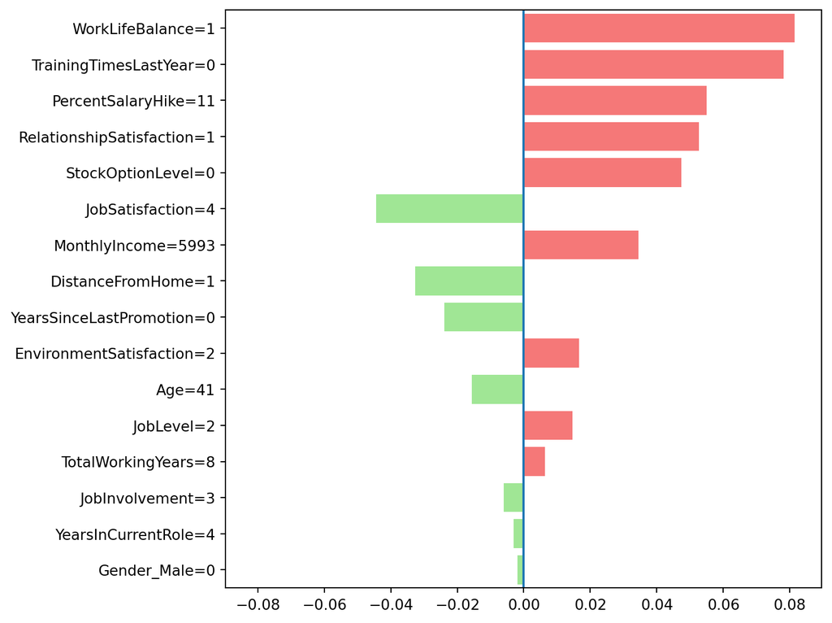

```python
# 建立變數名稱與對應值的表示，方便繪圖標籤
var_name_val = ['%s=%s' % (shap_df['name'].iloc[k], shap_df['value'].iloc[k]) for k in range(len(shap_df))]
shap_draw_order = np.flip(np.arange(len(shap_df)))  # 定義繪圖順序
shap_pos_loc = np.where(shap_df['mean'] >= 0)  # 找出 SHAP 貢獻值為正的位置
shap_neg_loc = np.where(shap_df['mean'] < 0)  # 找出 SHAP 貢獻值為負的位置
shap_ext = np.max(np.abs(shap_df['mean'])) * 1.1  # 定義繪圖的 x 軸範圍（略大於最大值）

# 繪製 SHAP 條形圖
fig = plt.figure(figsize=(8, 6))  # 定義圖形大小
ax = plt.subplot(1, 1, 1)  # 建立子圖
ax.barh(shap_draw_order[shap_pos_loc], shap_df['mean'].iloc[shap_pos_loc].tolist(), color='#f57878')  # 繪製正貢獻值條形圖
ax.barh(shap_draw_order[shap_neg_loc], shap_df['mean'].iloc[shap_neg_loc].tolist(), color='#a0e695')  # 繪製負貢獻值條形圖
ax.vlines(0, np.min(shap_draw_order)-1, np.max(shap_draw_order)+1)  # 繪製中心垂直線
ax.set_yticks(shap_draw_order)  # 設定 y 軸刻度
ax.set_yticklabels(var_name_val)  # 設定 y 軸標籤為變數名稱與值
ax.set_xlim((-shap_ext, shap_ext))  # 設定 x 軸範圍
ax.set_ylim((np.min(shap_draw_order)-.5, np.max(shap_draw_order)+.5))  # 設定 y 軸範圍
fig.tight_layout()  # 自動調整圖形布局
fig.show()  # 顯示圖形
```

### 檢視資料中第 21 位同仁是否有離職意願，並推測可能原因

取第 21 位同仁的資料，丟入模型預測

```python
mdl.predict(x.iloc[[21]])
```

```
array([1])
```

預測結果為 `1`，表示該員工有離職意願。使用 DALEX 模型解釋器計算 SHAP，推測該員工可能的離職的原因。

```python
# 使用 SHAP（SHapley Additive exPlanations）解釋模型結果
shap_result_21 = expl.predict_parts(x.iloc[[21]], type='shap', B=10, random_state=0).result

# 初始化 DataFrame，儲存 SHAP 分數與對應變數資訊
shap_df_21 = pd.DataFrame(columns=['name', 'value', 'mean'])
# 獲取所有變數的名稱
x_vars = np.unique(shap_result_21['variable_name'])
# 遍歷每個變數並計算其 SHAP 分數的平均值
for j in range(len(x_vars)):
    tmp = deepcopy(shap_result_21.loc[shap_result_21['variable_name'] == x_vars[j],])  # 深層複製當前變數的數據
    scores = tmp.loc[tmp['B'] > 0, 'contribution'].values  # 提取貢獻值（僅包含 B > 0 的行）
    x_value = tmp.loc[tmp['B'] == 0, 'variable_value'].values[0]  # 提取變數值
    shap_df_21.loc[j] = [x_vars[j], x_value] + [np.mean(scores)]  # 將變數名稱、值與平均貢獻值存入 DataFrame

# 計算 SHAP 平均值的絕對值並進行排序
shap_df_21['abs_mean'] = np.abs(shap_df_21['mean'])  # 計算貢獻值的絕對平均值
shap_df_21.sort_values('abs_mean', ascending=False, inplace=True, ignore_index=True)  # 按絕對值降序排序
shap_df_21.replace(np.nan, None, inplace=True)  # 替換遺漏值為 None
```

以下為第 21 位同仁 SHAP 值的視覺化結果，紅色長條為使反應變數向 `1` 傾斜的推力（想離職的動力），綠色長條為使反應變數向 `0` 傾斜的拉力（願意繼續待的考量）。

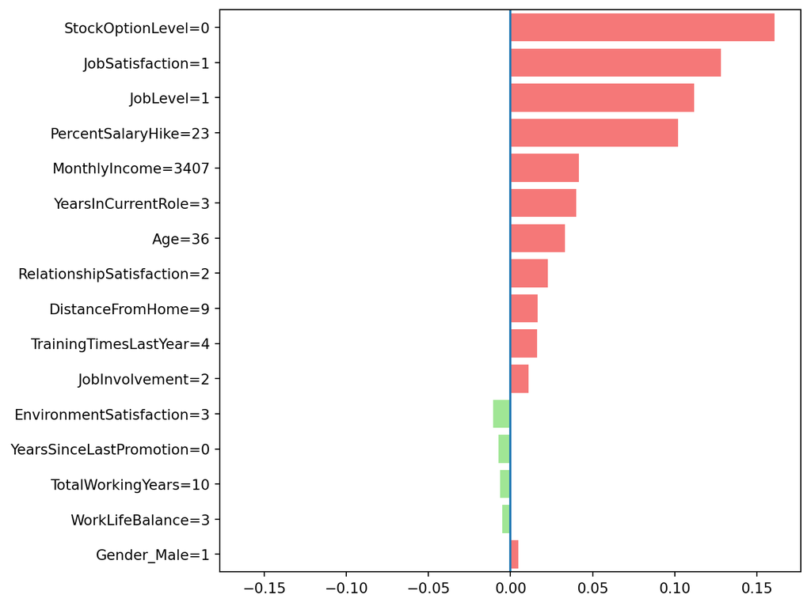